# Ekspresi Infiks ke Postfiks

urutan prioritasnya adalah sebagai berikut: (^) memiliki prioritas tertinggi dan dievaluasi dari kanan ke kiri, (* dan /) berada di urutan berikutnya dengan asosiatif dari kiri ke kanan, dan (+ dan -) memiliki prioritas terendah dengan asosiatif dari kiri ke kanan.

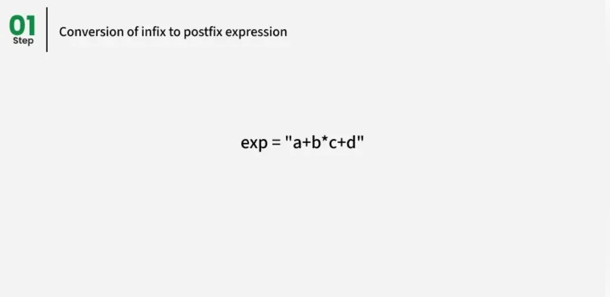

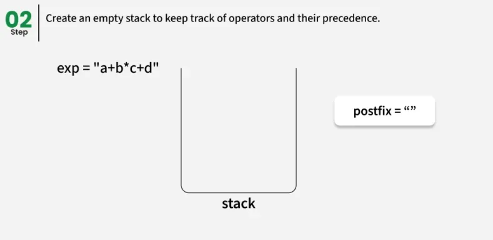

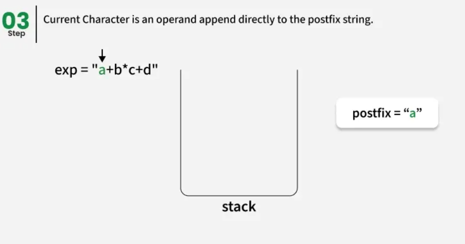

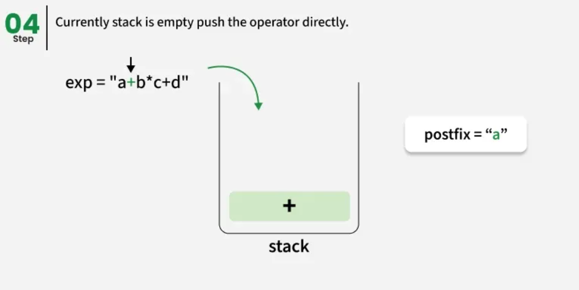

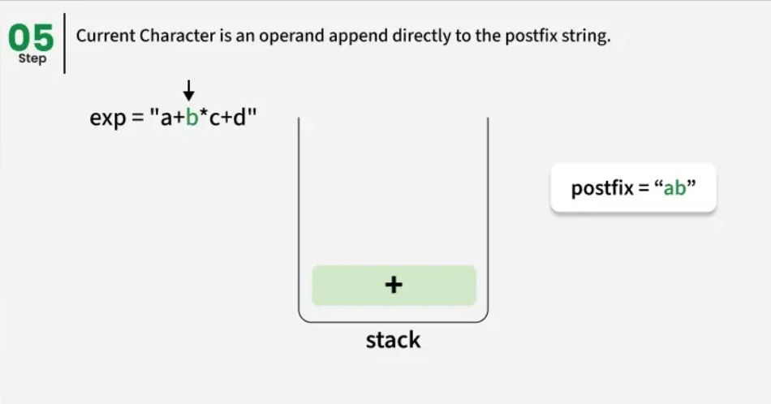

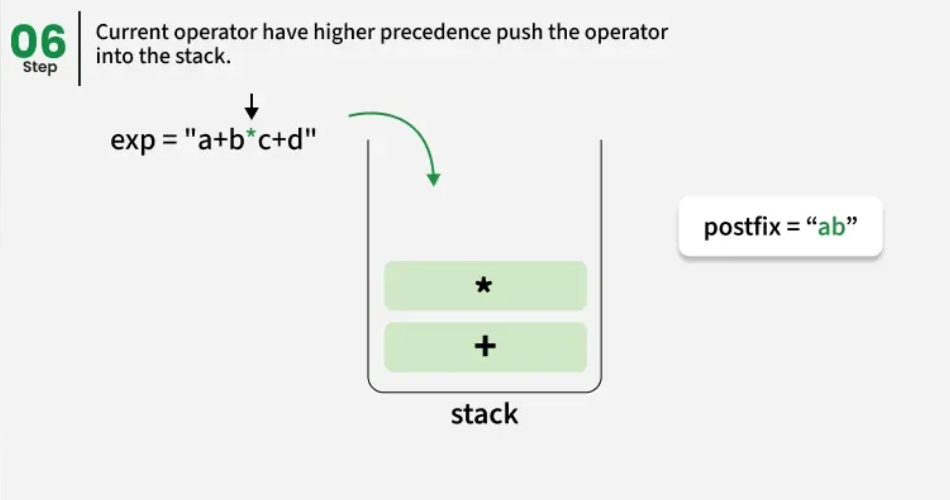

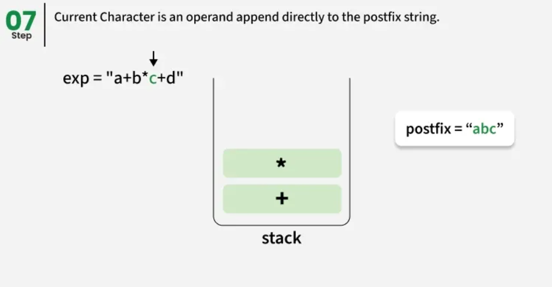

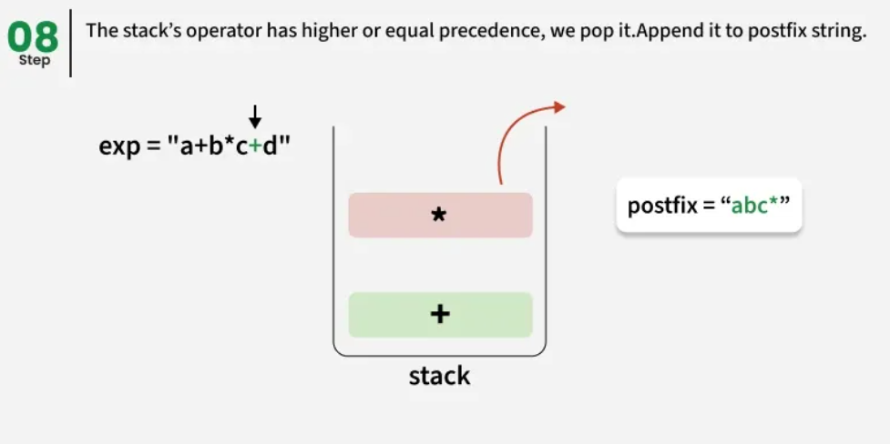

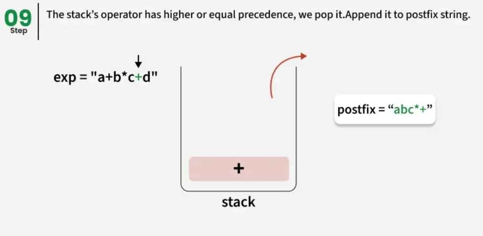

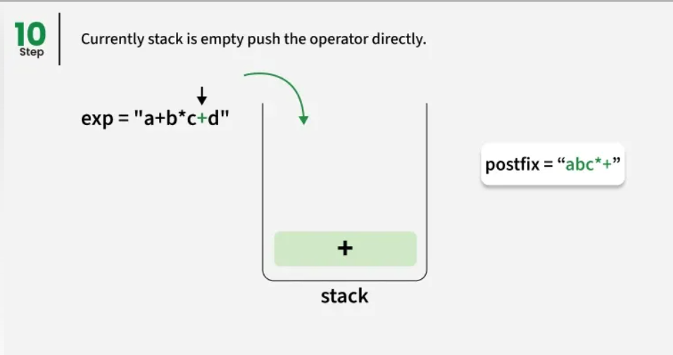

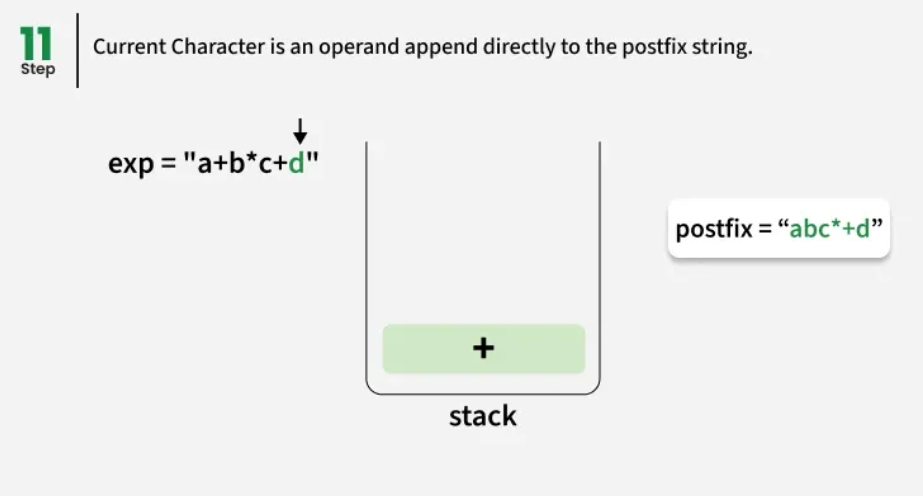

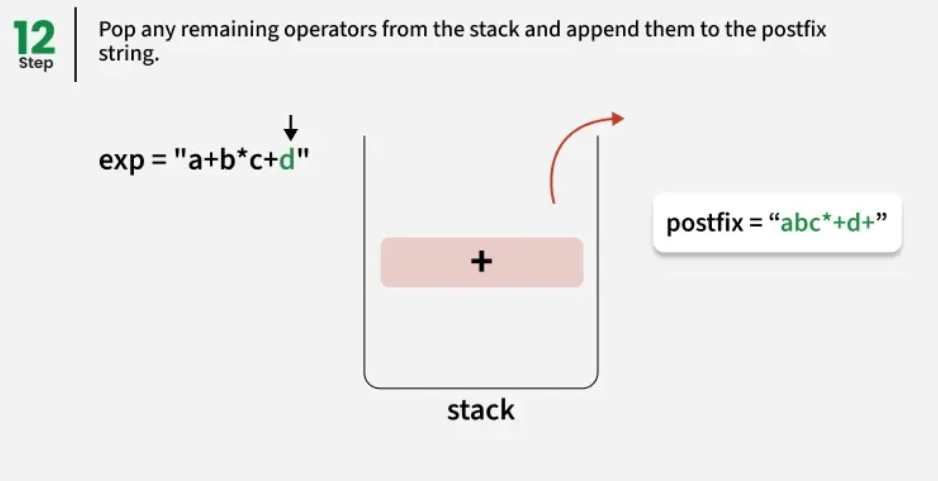

```python
def prec(c):
    if c == '^':
        return 3
    elif c == '/' or c == '*':
        return 2
    elif c == '+' or c == '-':
        return 1
    else:
        return -1

def isRightAssociative(c):
    return c == '^'

def infixToPostfix(s):
    st = []
    res = []

    for c in s:
        # If operand, add to result
        if ('a' <= c <= 'z') or ('A' <= c <= 'Z') or ('0' <= c <= '9'):
            res.append(c)

        # If '(', push to stack
        elif c == '(':
            st.append('(')

        # If ')', pop until '('
        elif c == ')':
            while st and st[-1] != '(':
                res.append(st.pop())
            st.pop()

        # If operator
        else:
            while st and st[-1] != '(' and \
                (prec(st[-1]) > prec(c) or (prec(st[-1]) == prec(c) \
                                    and not isRightAssociative(c))):
                res.append(st.pop())
            st.append(c)

    # Pop remaining operators
    while st:
        res.append(st.pop())

    return ''.join(res)

if __name__ == '__main__':
    exp = "a*(b+c)/d"
    print(infixToPostfix(exp))
```

```
abc+*d/
```

## Infix To Prefix Notation

Urutan prioritasnya adalah sebagai berikut: (^) memiliki prioritas tertinggi dan dievaluasi dari kanan ke kiri, (* dan /) berada di urutan berikutnya dengan asosiatif dari kiri ke kanan, dan (+ dan -) memiliki prioritas terendah dengan asosiatif dari kiri ke kanan.

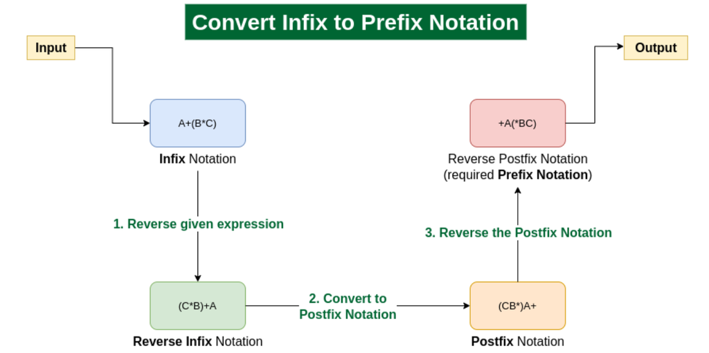

```python
def precedence(c):
    if c == '^': return 3
    elif c in ['*', '/']: return 2
    elif c in ['+', '-']: return 1
    else: return -1

def isOperator(c):
    return c in ['+', '-', '*', '/', '^']

# check if operator is right-associative
def isRightAssociative(c):
    return c == '^'

# function to convert infix to prefix
# using reverse-trick
def infixToPrefix(s):
    # reverse string
    s = s[::-1]

    # swap ( and )
    s = ''.join(')' if c == '(' else '(' if c == ')' else c for c in s)

    st = []
    result = []

    # infix to postfix on reversed string
    for c in s:
        if c.isalnum():
            result.append(c)
        elif c == '(':
            st.append(c)
        elif c == ')':
            while st and st[-1] != '(':
                result.append(st.pop())
            if st: st.pop()
        elif isOperator(c):
            while (st and st[-1] != '(' and
                   (precedence(st[-1]) > precedence(c) or
                   (precedence(st[-1]) == precedence(c) and isRightAssociative(c)))):
                result.append(st.pop())
            st.append(c)

    while st:
        result.append(st.pop())

    # reverse result
    return ''.join(result[::-1])

if __name__ == "__main__":
    s = "a*(b+c)/d"
    print(infixToPrefix(s))
```

```
/*a+bcd
```

## Prefix to Infix Conversion

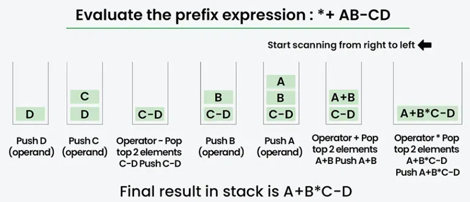

Algoritma untuk Konversi Awalan ke Sisipan :

Bacalah ekspresi Awalan secara terbalik (dari kanan ke kiri) Jika simbol tersebut merupakan operan, maka masukkan ke dalam Stack. Jika simbol tersebut adalah operator, maka keluarkan dua operand dari Stack. Buat string dengan menggabungkan kedua operand dan operator di antaranya. string = (operand1 + operator + operand2) Dan masukkan kembali string hasil tersebut ke Stack. Ulangi langkah-langkah di atas hingga akhir ekspresi Awalan. Pada akhirnya, tumpukan hanya akan berisi 1 string, yaitu string hasil.

```python
def prefixToInfix(prefix):
    stack = []

    # read prefix in reverse order
    i = len(prefix) - 1
    while i >= 0:
        if not isOperator(prefix[i]):

            # symbol is operand
            stack.append(prefix[i])
            i -= 1
        else:

            # symbol is operator
            str = "(" + stack.pop() + prefix[i] + stack.pop() + ")"
            stack.append(str)
            i -= 1

    return stack.pop()

def isOperator(c):
    if c == "*" or c == "+" or c == "-" or c == "/" or c == "^" or c == "(" or c == ")":
        return True
    else:
        return False

# Driver code
if __name__=="__main__":
    str = "*-A/BC-/AKL"
    print(prefixToInfix(str))
```

```
((A-(B/C))*((A/K)-L))
```

```python
class Stack:
     def __init__(self):
         self.items = []

     def isEmpty(self):
         return self.items == []

     def push(self, item):
         self.items.append(item)

     def pop(self):
         return self.items.pop()

     def peek(self):
         return self.items[len(self.items)-1]

     def size(self):
         return len(self.items)

def infixToPostfix(infixexpr):
    prec = {}
    prec["*"] = 3
    prec["/"] = 3
    prec["+"] = 2
    prec["-"] = 2
    prec["("] = 1
    opStack = Stack()
    postfixList = []

    tokenList = infixexpr


    for token in tokenList:
        if token in "ABCDEFGHIJKLMNOPQRSTUVWXYZ" or token in "0123456789":
            postfixList.append(token)
        elif token == '(':
            opStack.push(token)
        elif token == ')':
            topToken = opStack.pop()
            while topToken != '(':
                postfixList.append(topToken)
                topToken = opStack.pop()
        else:
            while (not opStack.isEmpty()) and \
               (prec[opStack.peek()] >= prec[token]):
                  postfixList.append(opStack.pop())
            opStack.push(token)

    while not opStack.isEmpty():
        postfixList.append(opStack.pop())

    return " ".join(postfixList)



infix = "A * ( B + C ) * D"
infix=infix[::-1]
infix=infix.split()
for i in range(len(infix)):
         if infix[i] == '(':
              infix[i]=')'
         elif infix[i] == ')':
              infix[i]='('
print(infix)
prefix=infixToPostfix(infix)
prefix=prefix[::-1]
print(prefix)
```

```
['D', '*', '(', 'C', '+', 'B', ')', '*', 'A']
* A * + B C D
```

```python
def infixToPostfix(infixexpr):
    prec = {"*": 3, "/": 3, "+": 2, "-": 2, "(": 1}

    # Menggunakan list standar Python sebagai Stack
    opStack = []
    postfixList = []

    # Memastikan token terpisah meskipun input tidak pakai spasi
    # Namun untuk kode ini, pastikan input tetap pakai spasi seperti contoh Anda
    tokenList = infixexpr.split()

    for token in tokenList:
        # Cek jika token adalah operand (huruf atau angka)
        if token.isalnum():
            postfixList.append(token)
        elif token == '(':
            opStack.append(token) # push
        elif token == ')':
            topToken = opStack.pop()
            while topToken != '(':
                postfixList.append(topToken)
                topToken = opStack.pop()
        else:
            # Mengganti opStack.peek() dengan opStack[-1] dan opStack.isEmpty() dengan len()
            while (len(opStack) != 0) and \
               (prec[opStack[-1]] >= prec[token]):
                  postfixList.append(opStack.pop())
            opStack.append(token) # push

    while len(opStack) != 0:
        postfixList.append(opStack.pop())

    return " ".join(postfixList)

# Uji Coba
print(infixToPostfix("A * B + C * D"))
print(infixToPostfix("( A + B ) * C - ( D - E ) * ( F + G )"))
```

```
A B * C D * +
A B + C * D E - F G + * -
```

```python
def postfixEval(postfixExpr):
    # Menggunakan list standar sebagai Stack
    operandStack = []
    tokenList = postfixExpr.split()

    for token in tokenList:
        # Menggunakan .isdigit() agar bisa mendeteksi angka lebih dari 1 digit (misal: "10")
        if token.isdigit():
            operandStack.append(int(token)) # push
        else:
            # Mengambil dua angka terakhir dari stack
            operand2 = operandStack.pop()
            operand1 = operandStack.pop()

            result = doMath(token, operand1, operand2)
            operandStack.append(result) # push hasil kembali ke stack

    return operandStack.pop()

def doMath(op, op1, op2):
    if op == "*":
        return op1 * op2
    elif op == "/":
        return op1 / op2
    elif op == "+":
        return op1 + op2
    else:
        return op1 - op2

# Uji Coba: (7 + 8) / (3 + 2) = 15 / 5 = 3.0
print(f"Hasil Evaluasi: {postfixEval('7 8 + 3 2 + /')}")
```

```
Hasil Evaluasi: 3.0
```

```python
class Stack:
     def __init__(self):
         self.items = []

     def isEmpty(self):
         return self.items == []

     def push(self, item):
         self.items.append(item)

     def pop(self):
         return self.items.pop()

     def peek(self):
         return self.items[len(self.items)-1]

     def size(self):
         return len(self.items)

def infixToPostfix(infixexpr):
    prec = {}
    prec["*"] = 3
    prec["/"] = 3
    prec["+"] = 2
    prec["-"] = 2
    prec["("] = 1
    opStack = Stack()
    postfixList = []

    tokenList = infixexpr


    for token in tokenList:
        if token in "ABCDEFGHIJKLMNOPQRSTUVWXYZ" or token in "0123456789":
            postfixList.append(token)
        elif token == '(':
            opStack.push(token)
        elif token == ')':
            topToken = opStack.pop()
            while topToken != '(':
                postfixList.append(topToken)
                topToken = opStack.pop()
        else:
            while (not opStack.isEmpty()) and \
               (prec[opStack.peek()] >= prec[token]):
                  postfixList.append(opStack.pop())
            opStack.push(token)

    while not opStack.isEmpty():
        postfixList.append(opStack.pop())

    return " ".join(postfixList)



infix = "A * ( B + C ) * D"
infix=infix[::-1]
infix=infix.split()
for i in range(len(infix)):
         if infix[i] == '(':
              infix[i]=')'
         elif infix[i] == ')':
              infix[i]='('
print(infix)
prefix=infixToPostfix(infix)
prefix=prefix[::-1]
print(prefix)
```

```
['D', '*', '(', 'C', '+', 'B', ')', '*', 'A']
* A * + B C D
```

```python
class Stack:
     def __init__(self):
         self.items = []

     def isEmpty(self):
         return self.items == []

     def push(self, item):
         self.items.append(item)

     def pop(self):
         return self.items.pop()

     def peek(self):
         return self.items[len(self.items)-1]

     def size(self):
         return len(self.items)

def postfixEval(postfixExpr):
    operandStack = Stack()
    tokenList = postfixExpr.split()

    for token in tokenList[::-1]:
        if token in "0123456789":
            operandStack.push(int(token))
        else:
            operand2 = operandStack.pop()
            operand1 = operandStack.pop()
            result = doMath(token,operand1,operand2)
            operandStack.push(result)
    return operandStack.pop()

def doMath(op, op1, op2):
    if op == "*":
        return op1 * op2
    elif op == "/":
        return op1 / op2
    elif op == "+":
        return op1 + op2
    else:
        return op1 - op2

print(postfixEval('* + 4 5 8'))
```

```
72
```